# README

# Web App for Riparian Models

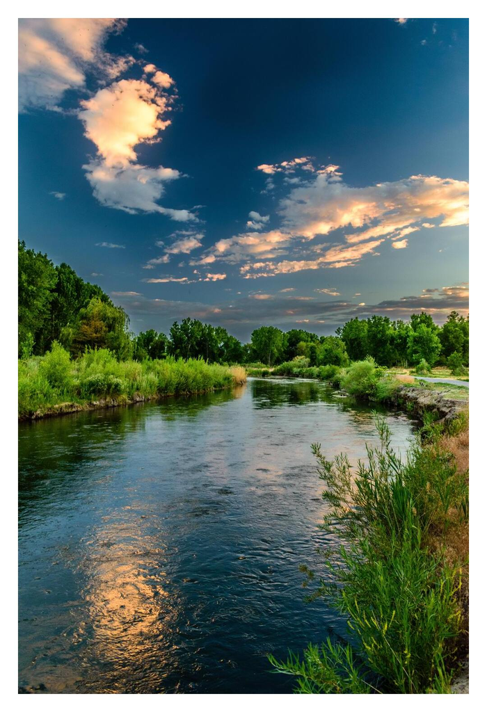

The **Web App for Riparian Models**, or **WARM** is a graphical user-interface that can be used to conduct riparian assessment calculations using select and existing riparian models. Users may interact with a menu which helps guide the user to aid in searching for a riparian model and their respective calculators. This web app evaluates riparian models using “Review of Riparian Models for Assessing Ecological Impacts and Benefits” (Wiest et al.,2003) by evaluating the existing riparian tools relative to model objectives, modeling approach, and input variables via user input.

More information on the “Review of Riparian Models for Assessing Ecological Impacts and Benefits” can be found on the Paper Link or the *Website* subtab on this app. Information pertaining to the WRISES team and their ongoing work can be found on the [WRISES GitHub](https://github.com/USACE-WRISES).

Contributors: Colton Shaw (Colton.K.Shaw@erdc.dren.mil), Samantha Weist, Kyle McKay (Kyle.McKay@usace.army.mil)

Release Date: 3/6/2023  
Version: 1.0.1  
Version Date: 3/6/2023  
Licensing: GPL-3  
Waiver: This model is provided for free as part of the USACE Technical Note “Robust Prediction of Hydraulic Roughness” by S. Kyle McKay and J. Craig Fischenich.  
Neither the authors nor the US Army Corps of Engineers accepts responsibility or liability for the model’s use by third parties.